# 8 Funciones vectoriales

## 8.1 Ejercicios Resueltos

Para la realización de esta práctica se requieren los siguientes paquetes:

```julia
using SymPy  # Para el cálculo simbólico.
using Plots  # Para el dibujo de gráficas.
using Makie, GLMakie # Para el dibújo de gráficas en 3d.
using LaTeXStrings  # Para usar código LaTeX en los gráficos.
using LinearAlgebra # Para el módulo, producto escalar y vectorial de vectores.
using Roots # Para calcular soluciones de ecuaciones numéricamente.
```

**Ejercicio 8.1** Representar gráficamente los vectores $\mathbf{u}=(3,1)$, $\mathbf{v}=(1,2)$ y $\mathbf{u}-\mathbf{v}$ en el plano real $\mathbb{R}^2$.

**Ayuda**

Usar la función [`plot`](https://aprendeconalf.es/manual-julia/graficos.html#gr%C3%A1fica-de-una-funci%C3%B3n-de-una-variable) del paquete `Plots`, añadiendo el parámetro `arrow = true` para dibujar flechas que representan vectores. También se puede usar la función [`arrows!`](https://docs.makie.org/stable/reference/plots/arrows) del paquete `Makie` para dibujar flechas.

**Solución**

**Plots**

```julia
using Plots
using LaTeXStrings
Plots.plot([0, 3], [0, 1], arrow = true, linewidth = 2, legend = false)
annotate!(1.5, 0.4, L"$\mathbf{u}$")
Plots.plot!([0, 1], [0, 2], arrow = true, linewidth = 2)
annotate!(0.4, 1, L"$\mathbf{v}$")
Plots.plot!([3, 1], [1, 2], arrow = true, linewidth = 2)
annotate!(2.1, 1.6, L"$\mathbf{u}-\mathbf{v}$")
```

[figure not shown]

**Makie**

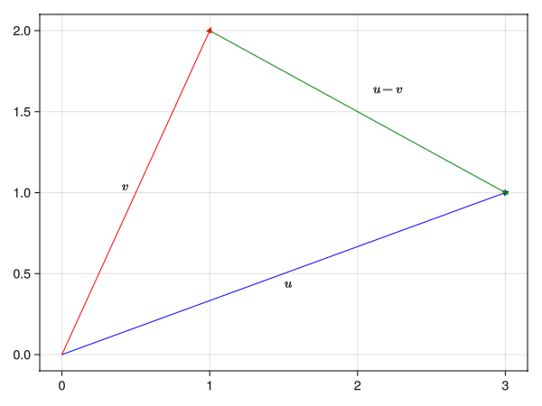

```julia
using GLMakie
using LaTeXStrings
o = Point2(0, 0)
u = Vec2(3, 1)
v = Vec2(1, 2)
fig = Figure()
ax = Axis(fig[1,1])
arrows!(ax, [o], [u], color = :blue)
text!(ax, 1.5, 0.4, text = L"$\mathbf{u}$")
arrows!(ax, [o], [v], color = :red)
text!(ax, 0.4, 1, text = L"$\mathbf{v}$")
arrows!(ax, [o+v], [u-v], color = :green)
text!(ax, 2.1, 1.6, text = L"$\mathbf{u}-\mathbf{v}$")
fig
```

   **Ayuda**

   Usar la función [`norm`](https://aprendeconalf.es/manual-julia/tipos-datos-compuestos.html#%C3%A1lgebra-lineal-con-vectores) del paquete `LinearAlgebra` para calular el módulo de un vector.

   **Solución**

   ```julia
   using LinearAlgebra
   u = [-1, 2, -1]
   v = [-2, 0, 1]
   println("Módulo de u: $(norm(u))")
   println("Módulo de v: $(norm(v))")
   println("Vector unitario con la dirección de u $(u/norm(u))")
   println("Vector unitario con la dirección de v $(v/norm(v))")
   ```

   ```
   Módulo de u: 2.449489742783178
   Módulo de v: 2.23606797749979
   Vector unitario con la dirección de u [-0.4082482904638631, 0.8164965809277261, -0.4082482904638631]
   Vector unitario con la dirección de v [-0.8944271909999159, 0.0, 0.4472135954999579]
   ```

2. Calcular su producto escalar.

   **Ayuda**

   Usar la función [`dot`](https://aprendeconalf.es/manual-julia/tipos-datos-compuestos.html#%C3%A1lgebra-lineal-con-vectores) del paquete `LinearAlgebra` para calcular el producto escalar de dos vectores.

   **Solución**

   ```julia
   println("Producto escalar de u y v: $(dot(u, v))")
   # También se puede usar el clásico punto ⋅
   println("Producto escalar de u y v: $(u ⋅ v)")
   ```

   ```
   Producto escalar de u y v: 1
   Producto escalar de u y v: 1
   ```

3. Calcular su producto vectorial.

   **Ayuda**

   Usar la función [`cross`](https://aprendeconalf.es/manual-julia/tipos-datos-compuestos.html#%C3%A1lgebra-lineal-con-vectores) del paquete `LinearAlgebra` para calcular el producto vectorial de dos vectores.

   **Solución**

   ```julia
   println("Producto vectorial de u y v: $(cross(u, v))")
   # También se puede usar la clásica cruz ×
   println("Producto vectorial de u y v: $(u × v)")
   ```

   ```
   Producto vectorial de u y v: [2, 3, 4]
   Producto vectorial de u y v: [2, 3, 4]
   ```

4. Dibujar $\mathbf{u}$, $\mathbf{v}$ y $\mathbf{u}\times\mathbf{v}$ en el espacio real.

   **Solución**

   **Plots**

   ```julia
   using Plots
   uv = u × v
   Plots.plot([0, u[1]], [0, u[2]], [0, u[3]], arrow = true, linewidth = 2, xlabel = "X", ylabel = "Y", zlabel = "Z", legend = false)
   Plots.plot!([0, v[1]], [0, v[2]], [0, v[3]], arrow = true, linewidth = 2)
   Plots.plot!([0, uv[1]], [0, uv[2]], [0, uv[3]], arrow = true, linewidth = 2)
   ```

[figure not shown]

   **Makie**

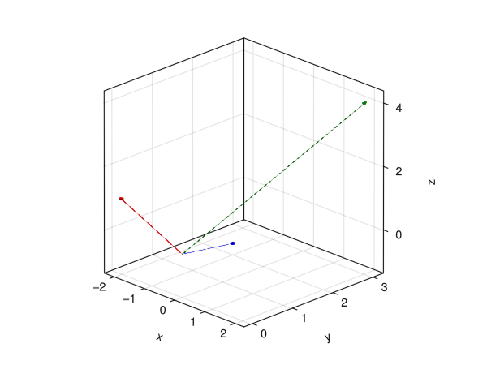

   ```julia
   using GLMakie
   fig = Figure()
   ax = Axis3(fig[1,1], azimuth = -pi/4, aspect = (1,1,1))
   O = [0, 0 ,0]
   arrows!(ax, [Point3(O)], [Vec3(u), Vec3(v), Vec3(u × v)],
       linecolor = [:blue,:red, :green], arrowcolor = [:blue,:red, :green],
       linewidth = 0.02, arrowsize = Vec3(0.1, 0.1, 0.1))
   fig
   ```

**Ejercicio 8.3** Dibujar las trayectorias de las siguientes funciones vectoriales.

1. $f(t)=(\operatorname{sen}(t), \cos(t))$.

   **Ayuda**

   Usar la función [`plot`](https://aprendeconalf.es/manual-julia/graficos.html#gr%C3%A1fica-de-una-funci%C3%B3n-de-una-variable) del paquete `Plots` o la función [`lines`](https://aprendeconalf.es/manual-julia/graficos.html#diagrama-de-l%C3%ADneas) del paquete `Makie` para dibujar la trayectoria, pasándole cada una de las funciones componentes separadas por comas.

   **Solución**

   **Plots**

   ```julia
   using Plots
   f(t) = [sin(t), cos(t)]
   ts = range(0, 2pi, length = 200)
   xs = [f(t)[1] for t in ts]
   ys = [f(t)[2] for t in ts]
   Plots.plot(xs, ys, aspect_ratio = :equal)
   ```

[figure not shown]

   **Makie**

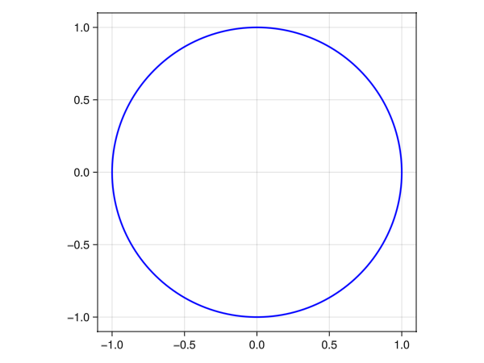

   ```julia
   using GLMakie
   f(t) = [sin(t), cos(t)]
   ts = range(0, 2pi, length = 200)
   points = Point2.(f.(ts))
   fig = Figure()
   ax = Axis(fig[1,1], aspect = 1)
   lines!(ax, points, linewidth = 2, color = :blue)
   fig
   ```

2. $\mathbf{g}(t) = (\cos(t), \operatorname{sen}(t), t/4)$.

   **Solución**

   **Plots**

   ```julia
   g(t) = [cos(t), sin(t), t/4]
   ts = range(0, 2pi, length = 200)
   xs = [g(t)[1] for t in ts]
   ys = [g(t)[2] for t in ts]
   zs = [g(t)[3] for t in ts]
   Plots.plot(xs, ys, zs, aspect_ratio = :equal, xlabel = "X", ylabel = "Y", zlabel = "Z", label = "")
   ```

[figure not shown]

   **Makie**

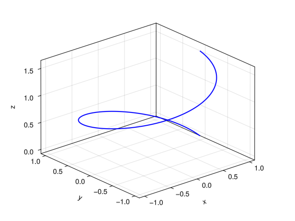

   ```julia
   using GLMakie
   g(t) = [cos(t), sin(t), t/4]
   ts = range(0, 2pi, length = 200)
   points = Point3.(g.(ts))
   fig = Figure()
   ax = Axis3(fig[1,1])
   lines!(ax, points, linewidth = 2, color = :blue)
   fig
   ```

**Ejercicio 8.4** Un [nudo tórico](https://en.wikipedia.org/wiki/Torus_knot) es un nudo que se forma mediante una trayectoria que gira sobre la superficie de un toro en $\mathbb{R}^3$. La función vectorial que define este tipo de nudos sobre un toro de ecuación $(r-2)^2+z^2 = 1$ es $\mathbf{f}(t) = ((2+\cos(qt))\cos(pt), (2+\cos(qt))\operatorname{sen}(pt), -\operatorname{sen}(qt))$, donde $p$ y $q$ son dos enteros primos entre si y $t\in [0,2\pi]$.

1. Dibujar el nudo tórico con $p=2$ y $q=3$.

   **Solución**

   Usando el paquete `Makie`.

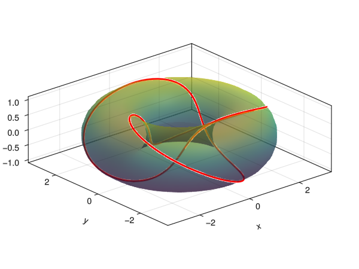

   ```julia
   using GLMakie
   # Definimos las ecuaciones paramétricas del toro.
   U = range(-pi, pi, 100)
   V = range(-pi, pi, 20)
   x1 = [2cos(u) + cos(u) * cos(v) for u in U, v in V]
   y1 = [2sin(u) + sin(u) * cos(v) for u in U, v in V]
   z1 = [sin(v) for u in U, v in V]
   # Inicializamos la figura y los ejes.
   fig = Figure()
   ax = Axis3(fig[1,1], aspect = (3, 3, 1))
   # Dibujamos el toro.
   Makie.surface!(ax, x1, y1, z1; colormap = :viridis, transparency = true, alpha = 0.5)
   # Definimos la función vectorial de nudo tórico.
   f(t) = [(2+cos(3t))cos(2t), (2+cos(3t))sin(2t), -sin(3t)]
   # Generamos los puntos de la trayectoria del nudo tórico.
   ts = range(0, 2pi, length = 200)
   points = Point3.(f.(ts))
   # Dibujamos el nudo tórico.
   lines!(ax, points, linewidth = 3, color = :red)
   fig
   ```

2. Definir una función para crear nudos tóricos con parámetros `p` y `q` para los enteros que definen el toro y un parámetro opcional booleano `toro`, para dibujar el toro o no.

   **Solución**

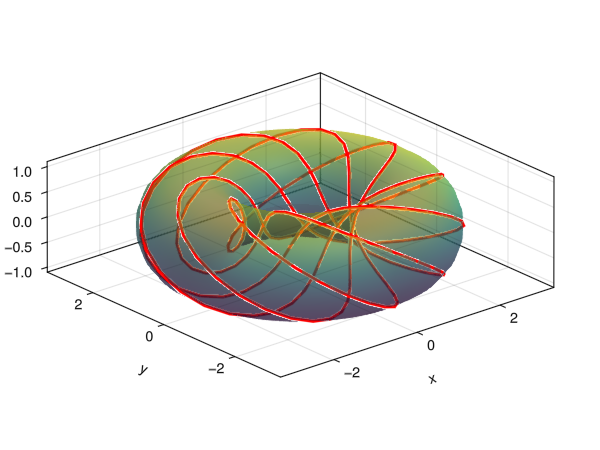

   ```julia
   using GLMakie
   """
       nudo_torico(ax, p, q, toro)

   Función dibuja un nudo tórico de parámetros p, q sobre los ejes ax. Si el parámetro toro es true dibuja también el toro sobre el que se traza el nudo.
   """
   function nudo_torico(ax::Axis3, p::Int64, q::Int64, toro::Bool = true)
       if toro
           alpha = 0.5
       else
           alpha = 0
       end
       # Definimos las ecuaciones paramétricas del toro.
       U = range(-pi, pi, 100)
       V = range(-pi, pi, 20)
       x1 = [2cos(u) + cos(u) * cos(v) for u in U, v in V]
       y1 = [2sin(u) + sin(u) * cos(v) for u in U, v in V]
       z1 = [sin(v) for u in U, v in V]
       # Dibujamos el toro en los ejes.
       Makie.surface!(ax, x1, y1, z1; colormap = :viridis, transparency = true, alpha = alpha)
       # Definimos la función vectorial de nudo tórico.
       f(t) = [(2+cos(q*t))cos(p*t), (2+cos(q*t))sin(p*t), -sin(q*t)]
       # Generamos los puntos de la trayectoria del nudo tórico.
       ts = range(0, 2pi, length = 200)
       points = Point3.(f.(ts))
       # Dibujamos el nudo tórico.
       lines!(ax, points, linewidth = 3, color = :red)
   end

   fig = Figure()
   ax = Axis3(fig[1,1], aspect = (3, 3, 1))
   nudo_torico(ax, 5, 9, true)
   fig
   ```

**Ejercicio 8.5**

1. Calcular las ecuaciones de la rectas tangente y normal a la trayectoria $\mathbf{f}(t) = (\operatorname{sen}(2t), \cos(t))$ en el punto correspondiente a $t=\pi/2$ y dibujarlas.

   **Ayuda**

   La ecuación de la recta tangente a la trayectoria de la función vectorial $\mathbf{f}(t)$ en el instante $t=a$ es $\mathbf{f}(a)+\mathbf{f}'(a)t$.

   La ecuación de la recta normal a la trayectoria de la función vectorial $\mathbf{f}(t)$ en el instante $t=a$ es $\mathbf{f}(a)+\mathbf{N}(a)t$, donde $\mathbf{N}(a)$ es un vector normal a $f'(a)$, como por ejemplo $\mathbf{N}(a) = (f'(a)_2, -f'(a)_1)$.

   **Solución**

   **Plots**

   ```julia
   using SymPy, Plots
   @syms t::real
   # Definimos la función vectorial.
   f(t) = [sin(2t), cos(t)]
   # Instante
   a = pi/2
   # Dibujamos la trayectoria.
   Plots.plot(f(t)..., 0, 2pi, aspect_ratio = :equal, label = "f(t)=(sen(t), cos(t))")
   # Dibujamos el punto de tangencia.
   Plots.scatter!([f(a)[1]],[f(a)[2]], label = "")
   # Calculamos la función derivada.
   df = lambdify(diff.(f(t)))
   # Calculamos la ecuación de la recta tangente.
   tl(t) = f(a) + df(a) * t
   # Dibujamos la recta tangente.
   Plots.plot!(tl(t)..., -1, 1, label = "Tangente")
   # Calculamos la ecuación de la recta normal.
   nl(t) = f(a) - [df(a)[2],-df(a)[1]] * t
   Plots.plot!(nl(t)..., -0.6, 0.6, label = "Normal")
   ```

[figure not shown]

   **Makie**

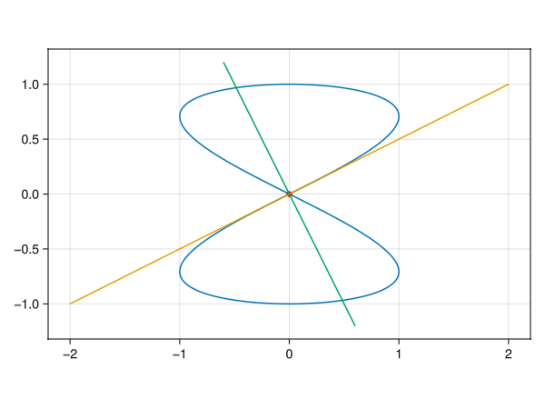

   ```julia
   using SymPy, GLMakie
   @syms t::real
   # Definimos la función vectorial.
   f(t) = [sin(2t), cos(t)]
   # Instante
   a = pi/2
   # Dibujamos la trayectoria.
   ts = range(0, 2pi, 200)
   points = Point2.(f.(ts))
   fig = Figure()
   ax = Axis(fig[1,1], aspect = DataAspect())
   lines!(ax, points)
   # Dibujamos el punto de tangencia.
   Makie.scatter!(Point2(f(a)), color = :red)
   # Calculamos la función derivada.
   df = lambdify(diff.(f(t)))
   # Calculamos la ecuación de la recta tangente.
   tl(t) = f(a) + df(a) * t
   # Dibujamos la recta tangente.
   pointstl = Point2.(tl.(range(-1, 1, 2)))
   lines!(ax, pointstl)
   # Calculamos la ecuación de la recta normal
   nl(t) = f(a) - [df(a)[2],-df(a)[1]] * t
   pointsnl = Point2.(nl.(range(-0.6, 0.6, 2)))
   lines!(ax, pointsnl)
   fig
   ```

2. Calcular las ecuaciones de las recta tangente y el plano normal a la trayectoria $\mathbf{g}(t) = (\cos(t), \operatorname{sen}(t), \sqrt{t})$ en punto correspondiente a $t=\pi/2$ y dibujarlas.

   **Solución**

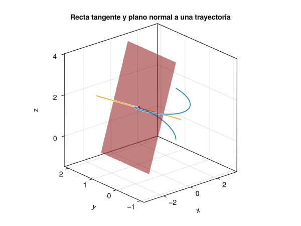

   ```julia
   using SymPy, LinearAlgebra, GLMakie
   @syms x, y, z, t
   # Definimos la función vectorial.
   g(t) = [cos(t), sin(t), sqrt(t)]
   # Instante
   a = pi/2
   # Dibujamos la trayectoria.
   ts = range(0, 2pi, 200)
   points = Point3.(g.(ts))
   fig = Figure()
   ax = Axis3(fig[1,1], title = "Recta tangente y plano normal a una trayectoria", aspect = :equal)
   lines!(ax, points)
   # Dibujamos el punto de tangencia.
   Makie.scatter!(Point3(g(a)), color = :red)
   # Calculamos la derivada en el punto.
   dg = lambdify(diff.(g(t)))
   # Calculamos la ecuación de la recta tangente.
   tl(t) = g(a) + dg(a) * t
   # Dibujamos la recta tangente.
   pointstl = Point3.(tl.(range(-pi, pi, 2)))
   lines!(ax, pointstl)
   # Calculamos la ecuación del plano normal
   np = lambdify(solve(dot(([x, y, z] - g(a)), dg(a)), z)[1])
   xs = range(-1, 1, 2)
   ys = range(0, 2, 2)
   zs = [np(x,y) for x in xs, y in ys]
   Makie.surface!(ax, xs, ys, zs, colormap = ["red"], alpha = 0.5, transparency = true)
   fig
   ```

**Ejercicio 8.6** Dada una función vectorial $\mathbf{f}(t)$ en $\mathbb{R}^3$, el *plano osculador* de la trayectoria de $\mathbf{f}(t)$ en $t=a$ es el plano definido por los vectores tangente $\mathbf{T}(a)$ y normal $\mathbf{N}(a)$.

Calcular y dibujar el plano osculador de la función vectorial del nudo tórico del apartado a del ejercicio Ejercicio 8.4 en el punto correspondiente a $t=\pi/2$.

**Solución**

Usando el paquete `Makie`.

[output not shown]

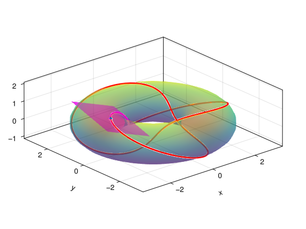

```julia
using SymPy, LinearAlgebra, GLMakie
@syms x, y, z, t::real
# Definimos las ecuaciones paramétricas del toro.
U = range(-pi, pi, 100)
V = range(-pi, pi, 20)
x1 = [2cos(u) + cos(u) * cos(v) for u in U, v in V]
y1 = [2sin(u) + sin(u) * cos(v) for u in U, v in V]
z1 = [sin(v) for u in U, v in V]
# Inicializamos la figura y los ejes.
fig = Figure()
ax = Axis3(fig[1,1], aspect = (3, 3, 1))
# Dibujamos el toro.
Makie.surface!(ax, x1, y1, z1; colormap = :viridis, shading = false, transparency = true, alpha = 0.5)
# Definimos la función vectorial de nudo tórico.
f(t) = [(2+cos(3t))cos(2t), (2+cos(3t))sin(2t), -sin(3t)]
# Generamos los puntos de la trayectoria del nudo tórico.
ts = range(0, 2pi, length = 200)
points = Point3.(f.(ts))
# Dibujamos el nudo tórico.
lines!(ax, points, linewidth = 3, color = :red)
# Punto
a = pi/2
# Dibujamos el punto.
Makie.scatter!(ax, Point3(f(a)))
# Vector tangente unitario.
Tan = lambdify(diff.(f(t)) / norm(diff.(f(t))))
# Vector normal unitario.
Norm = lambdify(diff.(Tan(t)) / norm(diff.(Tan(t))))
# Calculamos la ecuación del plano osculador.
po = lambdify(solve(dot(([x, y, z] - f(a)), cross(Tan(a), Norm(a))), z)[1])
xs = range(-3, -1, 2)
ys = range(-1, 1, 2)
zs = [po(x,y) for x in xs, y in ys]
Makie.surface!(ax, xs, ys, zs, colormap = ["magenta"], alpha = 0.8, transparency = true)
fig
```

**Ejercicio 8.7** Para construir un cuaderno de 30 cm de altura se utiliza una espiral de alambre con radio 1 cm y una distancia entre cada dos vueltas consecutivas $\pi/4$ cm. Dibujar la espiral y calcular la cantidad de alambre necesaria para cada cuaderno.

**Ayuda**

La [longitud de la trayectoria de una función vectorial](https://aprendeconalf.es/analisis-manual/12-funciones-vectoriales.html#longitud-de-la-trayectoria-de-una-funci%C3%B3n-vectorial) $\mathbf{f}(t)$ en el intervalo $t\in [a,b]$ se calcula mediante la integral

$$\int_a^b |\mathbf{f}'(t)|\, dt$$

**Solución**

Dibujamos primero la espiral.

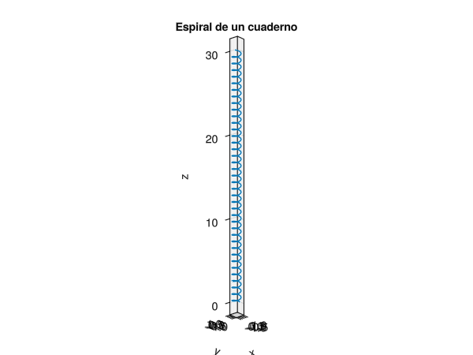

```julia
using SymPy, GLMakie
@syms t::real
# Definimos la función vectorial.
f(t) = [cos(t), sin(t), t/8]
# Calculamos el número de revoluciones.
h = N(solve(f(t)[3]-30)[1])
# Dibujamos la trayectoria.
ts = range(0, h, 2000)
points = Point3.(f.(ts))
fig = Figure()
ax = Axis3(fig[1,1], title = "Espiral de un cuaderno", aspect = (1, 1, 30))
lines!(ax, points)
fig
```

A continuación calculamos la longitud de la espiral.

```julia
using LinearAlgebra
# Calculamos longitud de la trayectoria
N(integrate(norm(diff.(f(t))), (t, 0, h)))
```

```
241.8677324489565
```

**Ejercicio 8.8** Dibujar la función de curvatura de campana de Gauss correspondiente a la función de densidad de una distribución normal estándar

$$f(x) = \frac{1}{\sqrt{2\pi}}e^{-x^2/2}.$$

¿En qué puntos la curvatura es nula? ¿Dónde la curvatura es máxima localmente?

**Ayuda**

La [curvatura de la gráfica de una función real](https://aprendeconalf.es/analisis-ejercicios/10-funciones-vectoriales.html#exr-curvatura-funcion) $f(x)$ se calcula mediante la fórmula

$$\kappa(x) = \frac{|f''(x)|}{(1+f''(x)^2)^{3/2}}.$$

**Solución**

Dibujamos primero la gráfica de la función y la de la función curvatura.

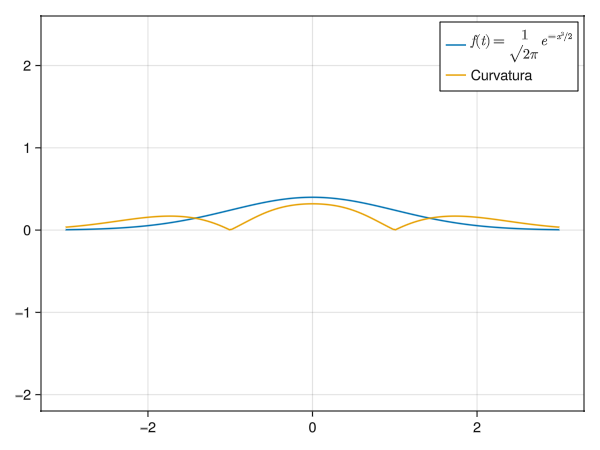

```julia
using SymPy, GLMakie
@syms x::real
# Definimos la función.
f(x) = 1/sqrt(2pi) * exp(-x^2/2)
# Dibujamos la gráfica de la función.
fig = Figure()
ax = Axis(fig[1,1], autolimitaspect = 1)
lines!(ax, -3..3, f, label = L"$f(t)= \frac{1}{\sqrt{2\pi}}e^{-x^2/2}$")
fig
# Calculamos la segunda derivada de la función.
df2 = lambdify(diff(f(x), x, 2))
# Calculamos la función de curvatura.
k(x) = abs(df2(x)) / (1 + df2(x)^2)^(3/2)
# Definimos una serie de puntos de la función curvatura.
xs = range(-3, 3, 200)
points = Point2.(xs, k.(xs))
# Dibujamos la función de curvatura
lines!(ax, points, label = "Curvatura")
# Añadimos la leyenda
axislegend()
fig
```

Ahora calculamos los puntos con curvatura máxima y mínima localmente.

```julia
# Calculamos los puntos que anulan la curvatura.
solve(k(x),x)
# Calculamos los puntos críticos de la curvatura.
# solve(diff(k(x)), x) No encuentra la solución, así que buscamos la solución numéricamente.
using Roots
println("Máximo local en x = $(find_zero(diff(k(x)), -2))")
println("Máximo local en x = $(find_zero(diff(k(x)), 0))")
println("Máximo local en x = $(find_zero(diff(k(x)), 2))")
```

```
Máximo local en x = -1.7320508075688772
Máximo local en x = 0.0
Máximo local en x = 1.7320508075688772
```

**Ejercicio 8.9** La *torsión* de una trayectoria de una función vectorial $\mathbf{f}(t)$ en el espacio real $\mathbb{R}^3$ mide la intensidad con la que una curva se sale del plano osculador y se calcula con la fórmula

$$\tau(t) = \frac{(\mathbf{f}'(t)\times \mathbf{f}''(t))\mathbf{f}'''(t)}{|\mathbf{f}'(t)\times \mathbf{f}''(t)|^2}$$

**Solución**

Calculamos primero la curvatura.

```julia
using SymPy, LinearAlgebra
"""
    curvatura(h, a)

Calcula la curvatura de la trayectoria de una función vectorial h en el punto a.
"""
function curvatura(f, a)
    @syms t::real
    # Calculamos la primera derivada.
    df(t) = diff.(f(t))
    # Calculamos la segunda derivada.
    df2(t) = diff.(df(t))
    # Calculamos la curvatura
    k(t) = norm(cross(df(t), df2(t))) / norm(df(t))^3
    return N(subs(k(t), t=>a))
end

f(t) = [cos(2t), sin(t), cos(t)]
println("Curvatura en t=0: $(curvatura(f, 0))")
println("Curvatura en t=π/4: $(curvatura(f, pi/4))")
println("Curvatura en t=π/2: $(curvatura(f, pi/2))")
println("Curvatura en t=3π/4: $(curvatura(f, 3pi/4))")
```

```
Curvatura en t=0: 4.123105625617661
Curvatura en t=π/4: 0.2
Curvatura en t=π/2: 4.123105625617661
Curvatura en t=3π/4: 0.2
```

Y ahora calculamos la torsión.

```julia
using SymPy, LinearAlgebra
"""
    torsion(h, a)

Calcula la torsion de la trayectoria de una función vectorial h en el punto a.
"""
function torsion(f, a)
    @syms t::real
    # Calculamos la primera derivada.
    df(t) = diff.(f(t))
    # Calculamos la segunda derivada.
    df2(t) = diff.(df(t))
    # Calculamos la tercera derivada.
    df3(t) = diff.(df2(t))
    # Calculamos la torsión.
    τ(t) = dot(cross(df(t), df2(t)), df3(t)) / norm(cross(df(t), df2(t)))^2
    return N(subs(τ(t), t=>a))
end

println("Torsión en t=0: $(torsion(f, 0))")
println("Torsión en t=π/4: $(torsion(f, pi/4))")
println("Torsión en t=π/2: $(torsion(f, pi/2))")
println("Torsión en t=3π/4: $(torsion(f, 3pi/4))")
```

```
Torsión en t=0: 0
Torsión en t=π/4: -1.2000000000000002
Torsión en t=π/2: -4.3222828205200695e-17
Torsión en t=3π/4: 1.2000000000000002
```

**Ejercicio 8.10** Se lanza una pelota desde la terraza de un edificio de altura $h$ con una rapidez inicial $r$ y un ángulo sobre el horizonte $\theta$. Estudiar la trayectoria que describe la pelota suponiendo que la única fuerza que actúa sobre ella es la de la gravedad.

1. Definir una función para calcular la función vectorial de la posición de la pelota tomando como parámetros la altura del edificio, la rapidez inicial y el ángulo de lanzamiento.

   **Solución**

   ```julia
   using SymPy
   """
       pelota(h, r, θ)

   Devuelve un vector con las componentes de la función vectorial que define la posición de una pelota lanzada desde una altura h, con una rapidez r y un ángulo de lanzamiento θ con respecto al horizonte.
   """
   function pelota(h, r, θ)
       @syms t::positive
       # Constante con al aceleración de la gravedad
       g = 9.81
       # Posición inicial.
       p₀ = [0, h]
       # Velocidad inicial.
       v₀ = [r*cos(θ), r*sin(θ)]
       # Aceleración constante
       a(t) = [Sym(0), -g]
       # Obtenemos el vector velocidad integrando la aceleración.
       v(t) = integrate.(a(t), t) + v₀
       # Obtenemos el vector posición integrando el vector velocidad.
       pos = integrate.(v(t), t) + p₀
       return pos
   end
   ```

   ```
   pelota
   ```

2. Construir una función para dibujar la gráfica de la trayectoria de la pelota tomando como parámetros la altura del edificio, la rapidez inicial y el ángulo de lanzamiento.

   **Solución**

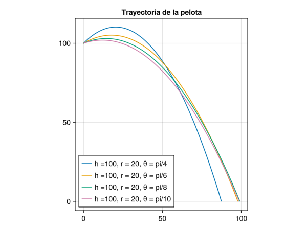

   ```julia
   using GLMakie
   """
       trayectoria_pelota(ax, h, r, θ)

   Dibuja sobre los ejes ax la gráfica de la trayectoria de una pelota lanzada desde una altura h, con una rapidez r y un ángulo de lanzamiento θ con respecto al horizonte.
   """
   function trayectoria_pelota!(ax, h, r, θ)
       @syms t::positive
       # Lambdificamos la función para poder llamarla con parámetros.
       f = lambdify(pelota(h, r, θ))
       # Calculamos el instante en el que la pelota toca el suelo.
       t₀ = N(solve(f(t)[2], t)[1])
       # Definimos un rango de valores desde 0 hasta el instante en que la pelota toca el suelo.
       ts = range(0, t₀, 200)
       # Obtenemos los puntos de la trayectoria.
       points = Point2.(f.(ts))
       # Dibujamos la trayectoria.
       lines!(ax, points, label = "h =$(h), r = $(r), θ = $(θ)")
       return ax
   end

   fig = Figure()
   ax = Axis(fig[1,1], title = "Trayectoria de la pelota", aspect = DataAspect())
   trayectoria_pelota!(ax, 100, 20, PI/4)
   trayectoria_pelota!(ax, 100, 20, PI/6)
   trayectoria_pelota!(ax, 100, 20, PI/8)
   trayectoria_pelota!(ax, 100, 20, PI/10)
   # Añadimos la leyenda
   axislegend(position = :lb)
   fig
   ```

3. Si se lanza la pelota a nivel del suelo, con una rapidez de 20 m/s ¿para qué ángulo se alcanzará una mayor distancia? ¿Y si se lanza desde 100 m de altura?

   **Solución**

   Calculamos primero el ángulo para una altura 0.

   ```julia
   @syms θ, t:: positive
   # Definimos la función vectorial.
   g(t) = pelota(0, 20, θ)
   # Calculamos el instante en que la pelota toca el suelo.
   t₀ = solve(g(t)[2], t)[1]
   # Calculamos los puntos críticos de la derivada de la posición horizontal de la pelota.
   solve(diff(subs(g(t)[1], t=>t₀), θ))
   ```

   $\left[\begin{smallmatrix}-0.785398163397448\\0.785398163397448\end{smallmatrix}\right]$

   Y ahora para una altura de 100 m.

   ```julia
   using Roots
   @syms θ, t:: positive
   # Definimos la función vectorial.
   g(t) = pelota(100, 20, θ)
   # Definimos la función vectorial.
   t₀ = solve(g(t)[2], t)[2]
   # Calculamos los puntos críticos de la derivada de la posición horizontal de la pelota.
   find_zero(diff(subs(g(t)[1], t=>t₀), θ), 0.5)
   ```

   ```
   0.3903970673218906
   ```

4. Determinar las componentes tangencial y normal del vector aceleración, para una altura de 100 m, una rapidez de 20 m/s y un ángulo $\pi/4$. Comprobar que la componente tangencial de la aceleración se anula en el mismo instante en el que la componente normal es máxima y cuando la pelota alcanza la máxima altura.

   **Ayuda**

   La componente tangencial del vector aceleración se puede calcular con la fórmula

   $$a_T(t) = |\mathbf{v}(t)|' = \frac{\mathbf{f}'(t)\mathbf{f}''(t)}{|\mathbf{f}'(t)|}.$$

   Y la componente normal mediante la fórmula

   $$a_N(t) = \kappa(t)|\mathbf{v}(t)|^2 = \frac{|\mathbf{f}'(t)\times \mathbf{f}''(t)|}{|\mathbf{f}'(t)|}.$$

   Si la trayectoria no es en el plano real, se pueden aplicar estas fórmulas añadiendo una tercera componente nula.

   **Solución**

   Calculamos primero la componente tangencial del vector aceleración.

   ```julia
   using LinearAlgebra
   @syms t::positive
   # Creamos la función vectorial
   g(t) = pelota(100, 20, PI/4)
   # Añadimos una tercera componente nula para estar en el espacio real.
   g3 = push!(g(t), 0)
   # Calculamos la primera derivada (vector velocidad).
   dg = diff.(g3, t)
   # Calculamos la segunda derivada (vector aceleración).
   dg2 = diff.(dg, t)
   # Calculamos la componente tangencial del vector aceleración.
   at = dot(dg, dg2) / norm(dg)
   ```

   $\frac{96.2361 t - 98.1 \sqrt{2}}{\sqrt{100 \left(0.981 t - \sqrt{2}\right)^{2} + 200}}$

   Y a continuación la componente normal.

   ```julia
   an = norm(cross(dg, dg2)) / norm(dg)
   ```

   $\frac{138.734350468801}{\sqrt{100 \left(0.981 t - \sqrt{2}\right)^{2} + 200}}$

   Ahora calculamos el instante en el que se anula la componente tangencial.

   ```julia
   solve(at)
   ```

   $\left[\begin{smallmatrix}1.4416040391163\end{smallmatrix}\right]$

   Finalmente comprobamos que es el mismo instante en el que la componente normal de la aceleración es máxima.

   ```julia
   # Instante en el que la componente normal de la acelaración es máxima.
   solve(diff(an))
   ```

   $\left[\begin{smallmatrix}1.4416040391163\end{smallmatrix}\right]$

   Y comprobamos también que coincide con el instante en que la pelota alcanza la máxima altura.

   ```julia
   solve(diff(g(t)[2]))
   ```

   $\left[\begin{smallmatrix}1.4416040391163\end{smallmatrix}\right]$

## 8.2 Ejercicios propuestos

**Ejercicio 8.11** Calcular el módulo del producto vectorial de los vectores $(-\pi,\sqrt{2},1)$ y $(\sqrt{3},-e,-2)$.

🎁

**Ejercicio 8.12** ¿A qué función vectorial le corresponde la trayectoria siguiente?

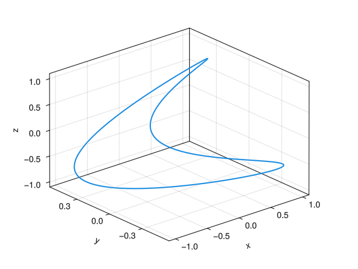

Las otras opciones son falsas.

\(f(t)=(\operatorname{sen}(2t), \cos(t)/2, \operatorname{sen}(t))\)

\(f(t)=(\operatorname{sen}(t)/2, \cos(2t), \cos(t))\)

\(f(t)=(\operatorname{sen}(t), \cos(2t), \cos(t)/2)\)

\(f(t)=(\cos(2t), \cos(t)/2, \operatorname{sen}(t/2))\)

**Ejercicio 8.13** Un mosquito sigue la trayectoria de la función $f(t)=(\cos(t), t/2, \ln(t+1))$. Si en el instante $t=1$ se sale por la tangente a la trayectoria, ¿a qué distancia del origen de coordenadas estará el mosquito en el instante $t=2$?

🎁

**Ejercicio 8.14** ¿Cuál de las siguientes ecuaciones es la del plano normal a la trayectoria de la función $g(t)=(\cos(t-1), \ln(\sqrt{t}), t^2)$ en el instante $t=1$?

\(2x-z=1\)

\(\frac{1}{4}y-z=1\)

Las otras opciones son falsas.

\(x+y+z=2\)

\(x+\frac{1}{2}y-z=0\)

**Ejercicio 8.15** Un avión sigue la trayectoria de la función $h(t)=(2t^2+t, \operatorname{sen}(t)+2cos(t), e^{-t/2})$.

1. ¿Qué distancia habrá recorrido desde instante $t=1$ hasta el instante $t=5$?

   🎁

2. ¿Cuál será la curvatura de la trayectoria en el instante $t=2$?

   🎁

3. ¿Cuál será la torsión de la trayectoria en el instante $t=2$?

   🎁

**Ejercicio 8.16** Un coche circula por una circuito elíptico cuya trayectoria viene dada por la función vectorial $f(t)=(400\cos(10t), 100\operatorname{sen}(10t))$, donde $t$ está dado en minutos y las coordenadas de $f$ en metros.

1. Calcular la rapidez del vehículo en el instante $t=\pi$.

   🎁

2. Calcular el módulo del vector aceleración en el mismo instante.

   🎁

3. Calcular la componente tangencial del vector aceleración en ese instante.

   🎁

4. Calcular la componente normal del vector aceleración en ese instante.

   🎁

5. Suponiendo que los neumáticos no proporcionan ningún agarre (por ejemplo porque hay hielo en la carretera), ¿Cuál es el mínimo ángulo que debería tener el peralte de la curva en este instante para que el coche no se salga del circuito? Tómese una aceleración debida a la gravedad de $9.8$ m/s$^2$.

   🎁